# Redefining rows: Wide vs narrow data organization

Data Computing Chapter 12

Presenter: Omar Hagrass  
Content credit: Matthew Beckman

# Cases, Variables, and Values

A data table is comprised of *cases* and *variables*.

Each *variable* comprises *values* (or levels).

There is no hard distinction between a variable and a value. What’s a variable in one situation may be a value in another, and vice versa.

A data table

```r
Kids
```

| who | age | sex | indoors | outdoors |
| --- | --- | --- | --- | --- |
| Eden | 9 | F | Gaming | Swimming |
| Jack | 6 | M | Trucks | Bicycle |
| Hazel | 3 | F | Puzzles | Playground |

# Cases, Variables, and Values

- Variables: `who`, `age`, `sex`, `indoors`, `outdoors`
  - Values:
    - `who` is a child’s name
    - `age` is numeric age
    - `sex` is sex of the child
    - `indoors` is a hobby while indoors
    - `outdoors` is a hobby while outdoors
- Cases: kids {Eden, Jack, Hazel}

| who | age | sex | indoors | outdoors |
| --- | --- | --- | --- | --- |
| Eden | 9 | F | Gaming | Swimming |
| Jack | 6 | M | Trucks | Bicycle |
| Hazel | 3 | F | Puzzles | Playground |

# Two formats

- Data in Key/Value format are **narrow**
  - possible to get *too* narrow if the meaning of case becomes awkward
- The corresponding **wide** format has
  - separate variables for each level in `key`
  - sets the values for those variables from the info in `value`

### Narrow

Q: What IS different? Q: What is NOT different?

```r
Kids %>%
  pivot_longer(cols = c(indoors, outdoors),
               names_to = "where", values_to = "hobby")
```

| who | age | sex | where | hobby |
| --- | --- | --- | --- | --- |
| Eden | 9 | F | indoors | Gaming |
| Eden | 9 | F | outdoors | Swimming |
| Jack | 6 | M | indoors | Trucks |
| Jack | 6 | M | outdoors | Bicycle |
| Hazel | 3 | F | indoors | Puzzles |
| Hazel | 3 | F | outdoors | Playground |

### (Too) Narrow

None of the data has been lost here, but it’s not a helpful form since there isn’t a useful definition of “case”.

| key | value |
| --- | --- |
| who | Eden |
| age | 9 |
| sex | F |
| indoors | Gaming |
| outdoors | Swimming |
| who | Jack |
| age | 6 |
| sex | M |
| indoors | Trucks |
| outdoors | Bicycle |
| who | Hazel |
| age | 3 |
| sex | F |
| indoors | Puzzles |
| outdoors | Playground |

### Wide

| who | age | sex | indoors | outdoors |
| --- | --- | --- | --- | --- |
| Eden | 9 | F | Gaming | Swimming |
| Jack | 6 | M | Trucks | Bicycle |
| Hazel | 3 | F | Puzzles | Playground |

# So what?

- This allows us to easily redefine how rows are presented in the data
  - Possibly motivated by the research question
  - Possibly motivated by desire to join two data tables with different case definitions
  - Possibly motivated by a data visualization
- Also, some operations are easy in wide format, but hard in narrow and *vice versa*
- We need tools that make it easy to switch back and forth

### Excerpt from `BabyNames`

| name | sex | count | year |
| --- | --- | --- | --- |
| Eden | F | 1927 | 2012 |
| Eden | M | 348 | 2012 |
| Eden | F | 2022 | 2013 |
| Eden | M | 377 | 2013 |
| Hazel | F | 1780 | 2012 |
| Hazel | F | 2039 | 2013 |
| Hazel | M | 6 | 2013 |
| Jack | F | 10 | 2012 |
| Jack | M | 7915 | 2012 |
| Jack | F | 6 | 2013 |
| Jack | M | 8506 | 2013 |

### Questions:

RQ 1. How many babies of each name and sex? RQ 2. For each name, is it primarily given to girls or boys? Which names are gender neutral?

# In narrow format

```r
data("BabyNames", package = "dcData")

BabyNames <-
  BabyNames %>%
  filter( name %in% c("Eden", "Jack", "Hazel"))
```

RQ 1. How many babies of each name and sex?

```r
BabyTotals <-
  BabyNames %>%
  group_by(name, sex) %>%
  summarise(total = sum(count))
```

```
## # A tibble: 6 x 3
## # Groups:   name [3]
##   name  sex    total
##   <chr> <chr>  <int>
## 1 Eden  F      23892
## 2 Eden  M       3640
## 3 Hazel F     238522
## 4 Hazel M       2644
## 5 Jack  F       2611
## 6 Jack  M     650847
```

Easy!

# In Wide format

RQ 2. Which names are most gender neutral?

```
WideOutput <-
  NarrowInput %>%
  pivot_wider(names_from = var1, values_from = var2, values_fill = 0)
```

- we want a new column for each category of `sex`, so `names_from = sex`
  - we will “unstack” each available category as a new variable (a.k.a. cast, spread, unfold)
  - categories of `sex` were “F” and “M” in this example
- the values/entries for our new variables are coming from `total`, so `values_from = total`
  - `values_fill = 0` specifies a default value to fill when missing

```r
BabyTotalsWide <-
  BabyTotals %>%
  pivot_wider(names_from = sex, values_from = total, values_fill = 0)

BabyTotalsWide
```

```
## # A tibble: 3 x 3
## # Groups:   name [3]
##   name       F      M
##   <chr>  <int>  <int>
## 1 Eden   23892   3640
## 2 Hazel 238522   2644
## 3 Jack    2611 650847
```

# With sexes side by side…

We can easily calculate balance associated with names

```r
BabyTotalsWide <-
  BabyTotalsWide %>%
  rename(fem = F, male = M) %>%         # `F` is a terrible variable name (why?)
  mutate(prop_fem  = fem  / (male + fem),
         prop_male = male / (male + fem),
         name_specificity = pmax(prop_fem, prop_male))    # what does `pmax()` do?

BabyTotalsWide
```

```
## # A tibble: 3 x 6
## # Groups:   name [3]
##   name     fem   male prop_fem prop_male name_specificity
##   <chr>  <int>  <int>    <dbl>     <dbl>            <dbl>
## 1 Eden   23892   3640  0.868      0.132             0.868
## 2 Hazel 238522   2644  0.989      0.0110            0.989
## 3 Jack    2611 650847  0.00400    0.996             0.996
```

# `pivot_longer( )`—when you have “Wide” and want “Narrow”

Syntax:

```
NarrowOutput <-
  WideInput %>%
  pivot_longer(cols = c(wide_var1, wide_var2, ...), names_to = "long_var1", values_to "long_var2")
```

- The `cols` are the variables we want to combine (a.k.a. melt, stack, fold, gather)
- e.g. `prop_fem` and `prop_male` in this case

```r
BabyTotalsNarrow <-
  BabyTotalsWide %>%
  select(prop_fem, prop_male) %>%
  pivot_longer(cols = c(prop_fem, prop_male), names_to = "sex", values_to = "proportion")
BabyTotalsNarrow
```

```
## # A tibble: 6 x 3
## # Groups:   name [3]
##   name  sex       proportion
##   <chr> <chr>          <dbl>
## 1 Eden  prop_fem     0.868
## 2 Eden  prop_male    0.132
## 3 Hazel prop_fem     0.989
## 4 Hazel prop_male    0.0110
## 5 Jack  prop_fem     0.00400
## 6 Jack  prop_male    0.996
```

# With sexes stacked again…

We can make an intuitive bar chart (though some clean up is needed…)

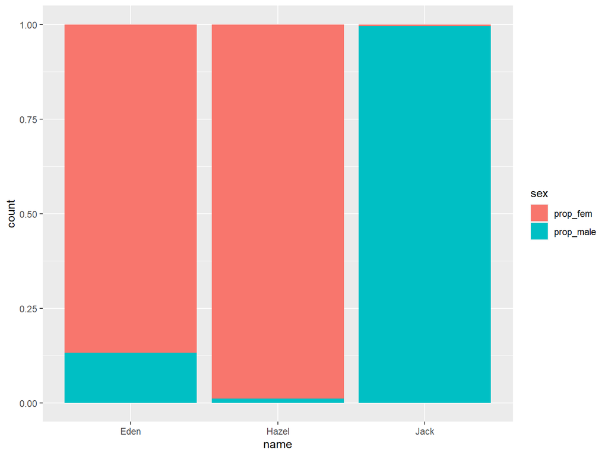

```r
BabyTotalsNarrow %>%
  ggplot() +
  geom_bar(aes(x = name, fill = sex, weight = proportion))
```

#### With some improvements

- clean up labels of sexes
- add title, source, & better axis labels (y-axis label had been flat wrong)

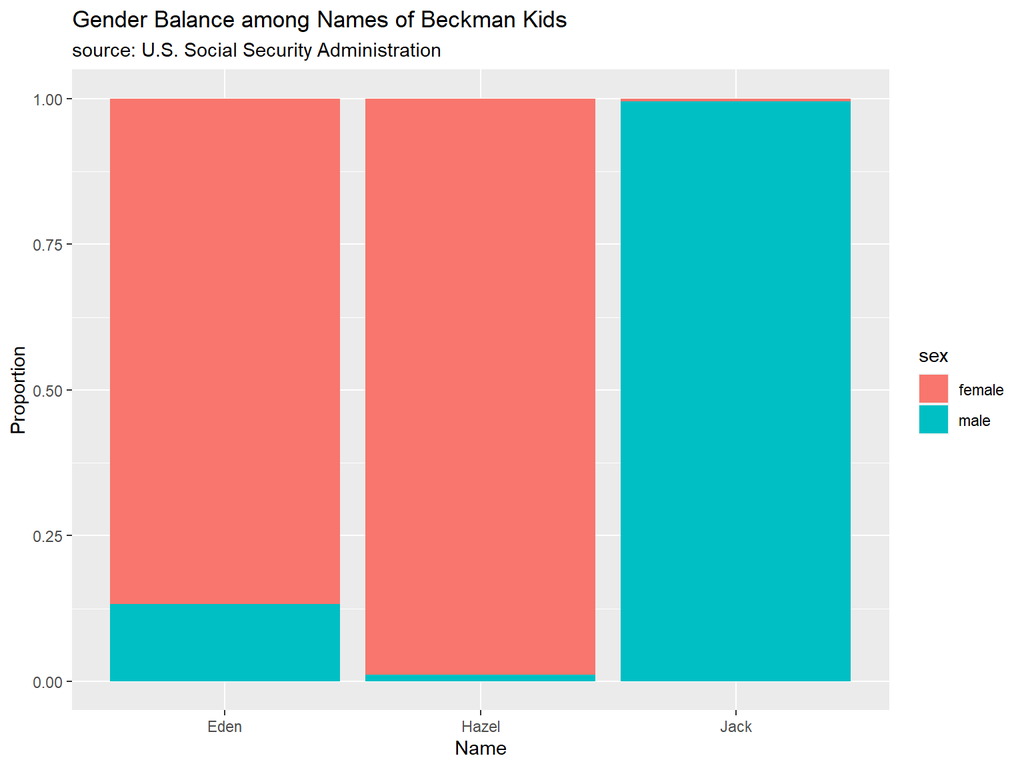

```r
# first, clean up the labels in `sex` for plotting
BabyTotalsNarrow %>%
  mutate(sex = if_else(sex == "prop_fem",
                       true = "female",
                       false = if_else(sex == "prop_male",
                                       true = "male",
                                       false = "unk")  # end of "inner" if_else()
                       )                               # ends the "outer" if_else()
         ) %>%                                         # ends the mutate()
  ggplot() +
  geom_bar(aes(x = name, fill = sex, weight = proportion)) +
  ggtitle("Gender Balance among Names of Beckman Kids",
          subtitle = "source: U.S. Social Security Administration") +
  xlab("Name") +
  ylab("Proportion")
```